# Avaliação Continuada - Aula 6

**Execute a célula a seguir para importar as bibliotecas de que vamos precisar e criar a variável `titanic` com nossa base de dados.**

```python
# Importando a biblioteca seaborn
import seaborn as sns
import matplotlib.pyplot as plt

# Carregando a base de dados 'titanic'
titanic = sns.load_dataset("titanic").query("fare > 15 and fare < 300 and pclass == 1")

titanic.head()
```

|  | survived | pclass | sex | age | sibsp | parch | fare | embarked | class | who | adult_male | deck | embark_town | alive | alone |
| --- | --- | --- | --- | --- | --- | --- | --- | --- | --- | --- | --- | --- | --- | --- | --- |
| 1 | 1 | 1 | female | 38.0 | 1 | 0 | 71.2833 | C | First | woman | False | C | Cherbourg | yes | False |
| 3 | 1 | 1 | female | 35.0 | 1 | 0 | 53.1000 | S | First | woman | False | C | Southampton | yes | False |
| 6 | 0 | 1 | male | 54.0 | 0 | 0 | 51.8625 | S | First | man | True | E | Southampton | no | True |
| 11 | 1 | 1 | female | 58.0 | 0 | 0 | 26.5500 | S | First | woman | False | C | Southampton | yes | True |
| 23 | 1 | 1 | male | 28.0 | 0 | 0 | 35.5000 | S | First | man | True | A | Southampton | yes | True |

### Sobre os dados

No exercício de hoje, vamos utilizar as variáveis:

- `fare`: indica o valor pago pela passagem, em dólares ($).
- `age`: indica a idade do passageiro, em anos.

### Exercício de hoje - Parte 1

Utilize a função `sns.scatterplot()` para criar um gráfico que mostre a relação entre o valor pago pela viagem (coluna `"fare"`) e a idade do passageiro (coluna `"age"`).

- Adote a convenção de eixos que vimos durante a aula, supondo que o valor pago pela viagem é a variável dependente ou de resposta, ao passo que a idade do passageiro é a variável independente ou explicativa.
- Adicione à função o argumento `alpha` com o valor de `0.8`, de forma a deixar os pontos semi-transparentes para que possamos verificar onde há sobreposições de pontos.

Após escrever a linha de código de sua resposta, execute a célula para mostrar o gráfico a partir da base `titanic`.

**Importante: antes de executar o código da sua resposta, não deixe de executar a célula de código que está no início deste caderno, que importa as bibliotecas e carrega os dados.**

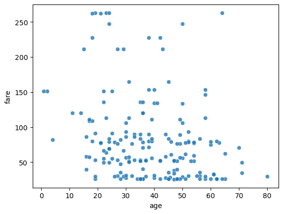

```python
# Escreva sua resposta abaixo e execute a célula para gerar o gráfico
sns.scatterplot(x="age", y="fare", alpha=0.8, data=titanic)
```

### Exercício de hoje - Parte 2

Execute novamente o mesmo gráfico, mas utilizando agora a função regplot para adicionar uma linha de tendência ao gráfico de pontos.

- Remova a sombra do intervalo de confiança atribuindo o valor `None` ao argumento `ci` da função `regplot`.
- Utilize o argumento `scatter_kws` da função regplot para que os pontos tenham um `alpha` de `0.8`. Para isso você precisa utilizar um dicionário com a chave `"alpha"` e o valor `0.8`.
- Utilize o argumento `line_kws` da função regplot para alterar a cor da linha de tendência. Para tanto, utilize novamente um dicionário, agora com a chave `"color"` e o valor referente à cor de sua escolha (`"red"`, por exemplo).

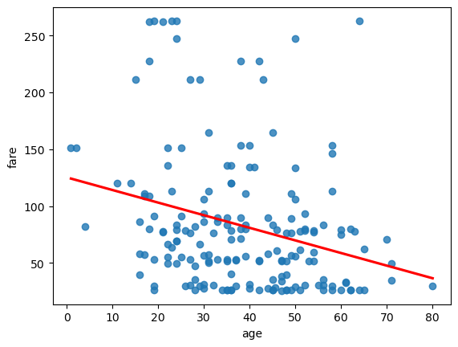

```python
# Escreva sua resposta abaixo e execute a célula para gerar o gráfico
sns.regplot(x="age", y="fare", ci=None, scatter_kws={"alpha":0.8}, line_kws={"color": "red"}, data=titanic)
```